# Robustness

This notebook is inspired by the examples of [Robust regression](https://rpubs.com/dvallslanaquera/robust_regression)

Extra resources from the course [From Data to Decisions: Measurement, Uncertainty, Analysis, and Modeling](http://www.lithoguru.com/scientist/statistics/course.html):

- [Robust statistics (youtube)](https://www.youtube.com/watch?v=AVDySygkMhM)
- [Robust regression (youtube)](https://www.youtube.com/watch?v=7a_6roLjwaA)
- [Robust regression in R (youtube)](https://www.youtube.com/watch?v=ru-WDbqfSGw)

```r
# install.packages("carData")
library(carData)
data(Duncan)
head(Duncan, n=10)
```

|  | type | income | education | prestige |
| --- | --- | --- | --- | --- |
| accountant | prof | 62 | 86 | 82 |
| pilot | prof | 72 | 76 | 83 |
| architect | prof | 75 | 92 | 90 |
| author | prof | 55 | 90 | 76 |
| chemist | prof | 64 | 86 | 90 |
| minister | prof | 21 | 84 | 87 |
| professor | prof | 64 | 93 | 93 |
| dentist | prof | 80 | 100 | 90 |
| reporter | wc | 67 | 87 | 52 |
| engineer | prof | 72 | 86 | 88 |

If we try to make a traditional linear regression we could see an abnormal pattern of the data, with some outliers:

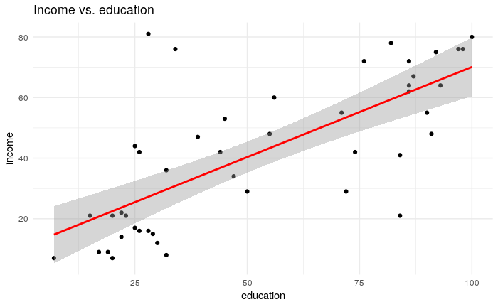

```r
library(tidyverse)
ggplot(Duncan, aes(x = education, y = income)) +
  geom_point() + stat_smooth(method = "lm", col = "red") + theme_minimal() +
  ggtitle("Income vs. education")
```

# 1. Outliers

See also [Measures of influence](https://cran.r-project.org/web/packages/olsrr/vignettes/influence_measures.html) in the orsrr package.

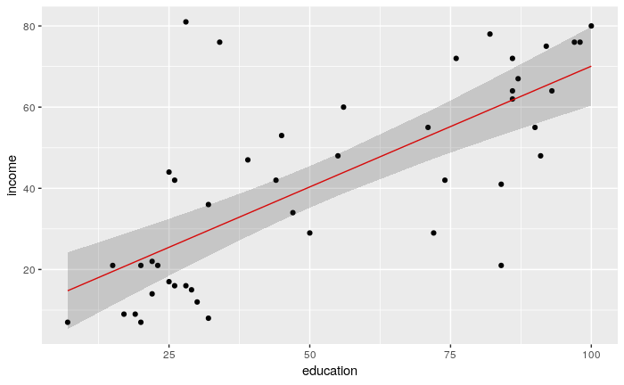

```r
# Now let's first create our linear model
fitLS <- lm(income ~ education, data = Duncan)
# than predict the income from the model, and add the fit column to the dataframe
duncan.predict <- cbind(Duncan,predict(fitLS, interval = "confidence"))
# An alternative way to build up the ggplot - add next steps to plot p:
p <- ggplot(duncan.predict, aes(education, income))
p <- p + geom_point()
p <- p + geom_line(aes(education, fit), color="red")
p <- p + geom_ribbon(aes(ymin=lwr,ymax=upr), alpha=0.2)
p
```

We can see in the plot three outliers which are messing up the linear regression method. It is clear that we have to try to solve this with a robust version of the regression method. To remove them is not option since they are not input errors, but real data which represents people who has an income unusually high considering their education level.

*Now we will use some extra measurements from [this blog](https://www.r-bloggers.com/regression-diagnostics-with-r/):*

### Assumptions

There are four assumptions of simple linear regression:

- Linear relationship between the two variables.
- Residuals are independent (can’t be tested statistically, so ignored for now).
- The residuals of the model are normally distributed.
- The variance of the residuals isn’t affected by the predicted value (homoscedasticity).

In addition to testing these assumptions, we also need to investigate any outliers, if any. So as well as the assumptions, we’ll check the:

- Cook’s distance
- Leverage (hat) values